# Assessing commercial fishery costs and benefits related to MPA network design

November 17, 2015

## Everything is open-access

Documentation

Case Study Paper

Code

Data

## The question:

**If MPA networks follow designn protocol X, Y, or Z, does the fishing industry stand to suffer or benefit financially?**

Atlantic cod case study scenarios:

- Status Quo
- Maximum Distance
- Fixed Distance
- Targeted

## Scenario 1: Status Quo

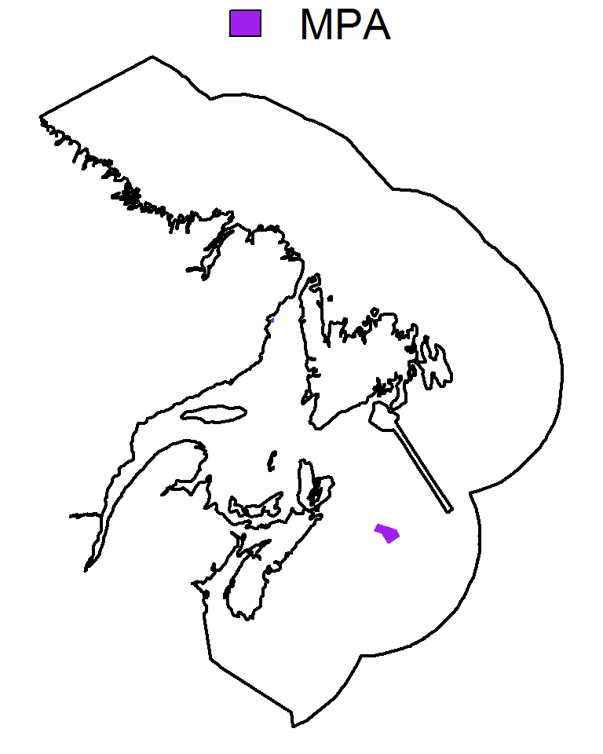

- only includes currently established MPAs

## Scenario 2: Maximum Distance

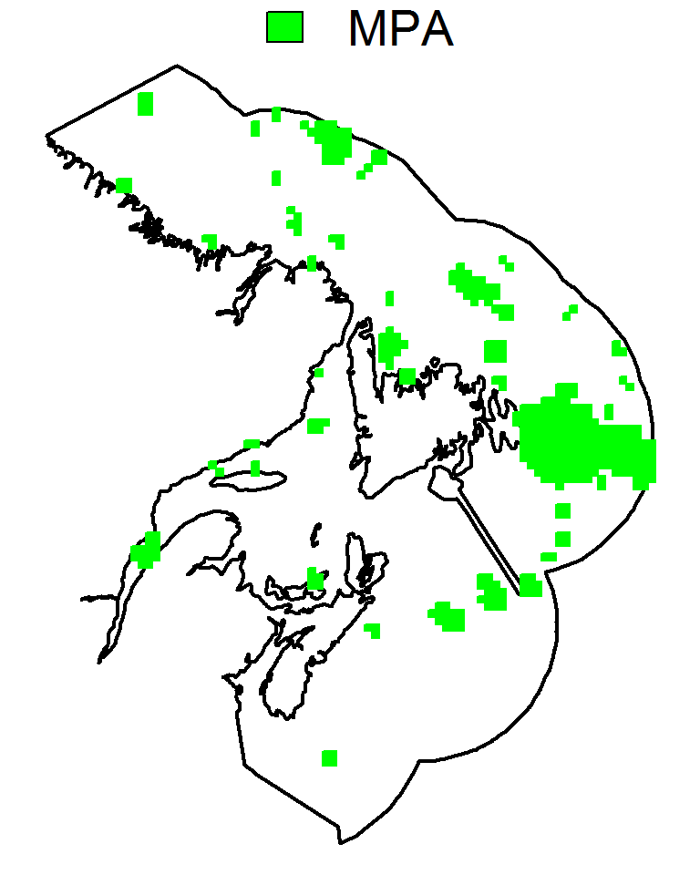

- minimizes population connectivity
- places MPAs as far as possible from nearest neighbours

## Scenario 3: Fixed Distance

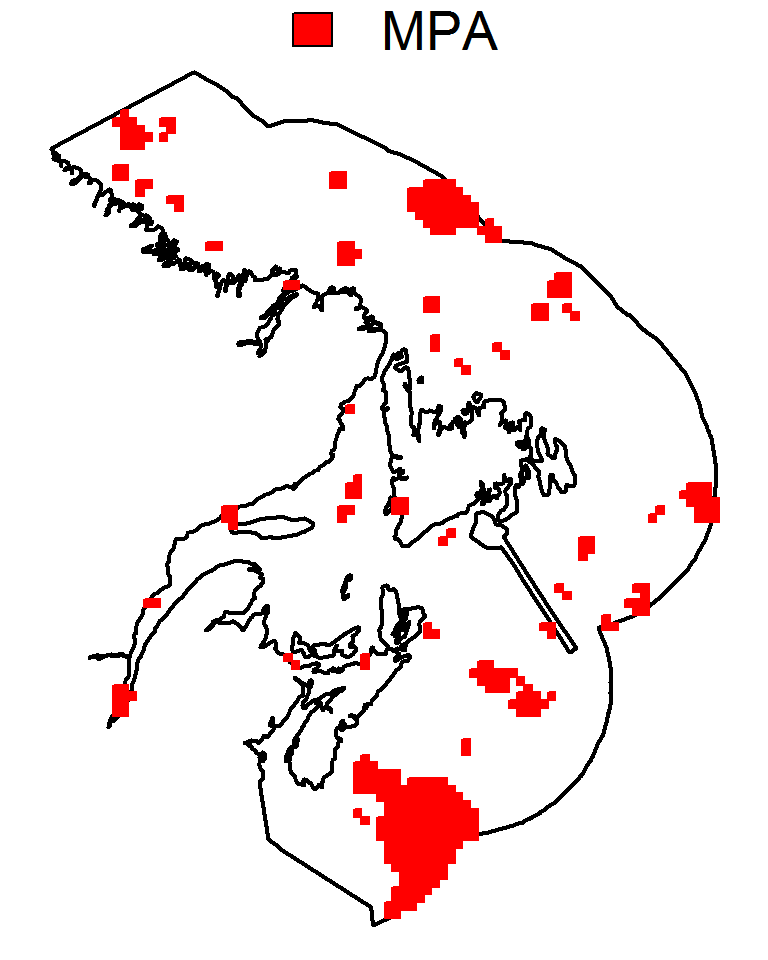

- optimizizes population connectivity
- places MPAs at a fixed distance from the nearest neighbours
- the distance is biologically relevant (i.e. dispersal distance)

## Scenario 4: Targeted

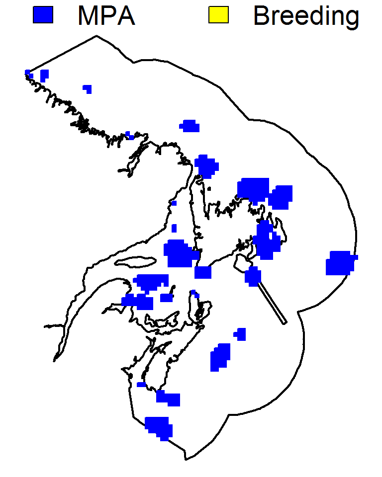

- maximizes biological relevance
- protects "breeding areas" by default
- places remaining MPAs at a fixed distance from the nearest neighbours

## Scenario 4: Targeted

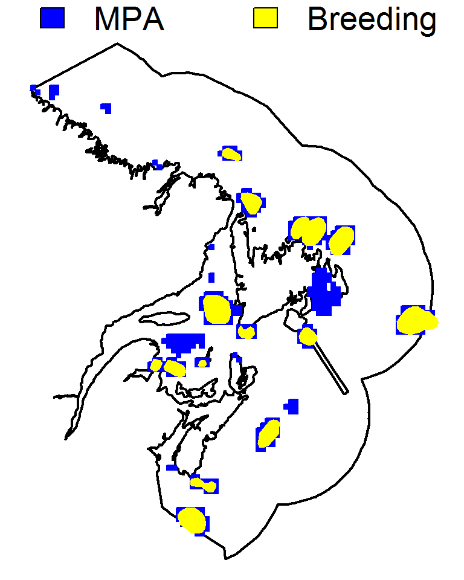

- maximizes biological relevance
- protects "breeding areas" by default
- places remaining MPAs at a fixed distance from the nearest neighbours

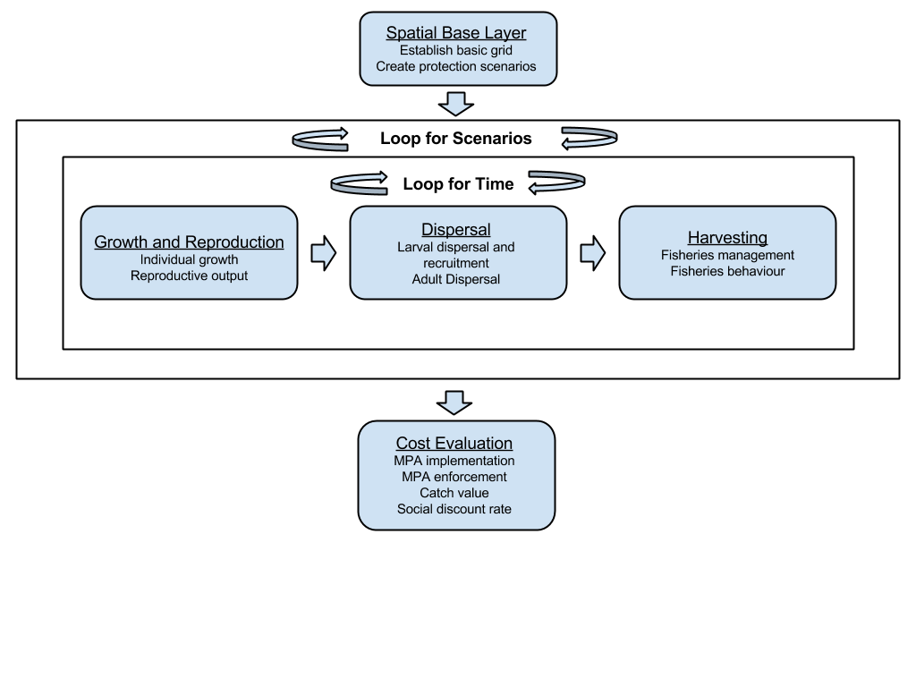

## The input: Spatial Base Layer

Shapefiles:

- EEZ
- Species' habitat
- Species' breeding areas
- Protection scenarios*

*may be generated at this step, or imported

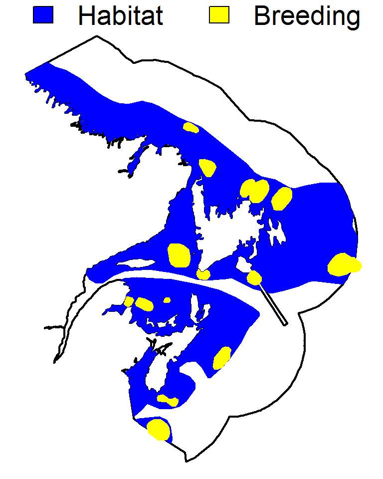

## The input: Growth and Reproduction

Von Bertalanffy growth model (Knickle and Rose 2013):

- Asymptotic length
- growth coefficient

Fecundity:

- Length-weight relationship (Knickle and Rose 2013)
- 500000 eggs/kg

## The input: Dispersal

*Adult:*

- Based on known migration distances

*Larval:*

**Built-in functionality**

The 'input' here can be connectivity matrices generated by:

- random dispersal (case study)
- simple biophysical dispersal models (ocean currents)
- complex biophysical dispersal models (larval behaviours)

## The input: Harvesting

**Effort**

effort = (1-rb[i])*rd[i]

where the *rb* is the biomass in cell *i* divided by the maximum biomass in the model domain and *rd* is the actual distance to shore for cell *i* divided by the mean distance to shore for all the cells in the model domain.

**MPAs & Moratorium**

Fishermen can't fish in MPAs. EEZ wide moratorium is triggered if biomass <10K tons

**Fishing ports**

Currently, anywhere on the coast, but the model could handle fine scale port data

## The input: Cost Evaluation

**MPA implementation & enforcement**

- not in case study

**Catch value:**

- gross landing value
- net = gross - operating costs

**Net Present Value:**

- we do not value things in the future as much as the present
- effectively the opposite of interest rates

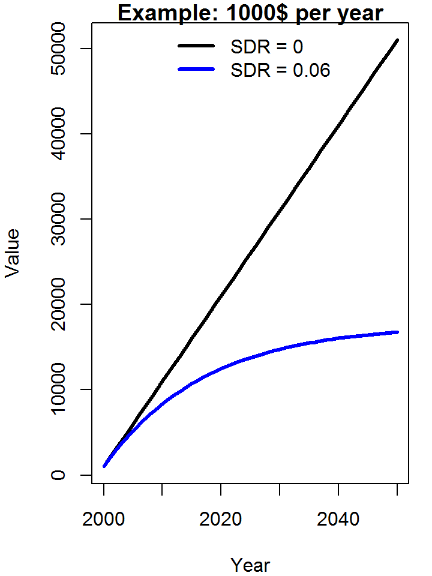

## Using the toolbox

[Downloading](https://github.com/remi-daigle/bioeconomic_MPA) the toolbox should allow users to **replicate the findings** presented in the [case study](http://f1000research.com/articles/4-1234/v1).

Users should be able to **substitute their own input** in 'user_input.R' to represent **different areas/species**.

Efforts were made to **modularize the code** so that users can 'easily' edit [modules/sub-modules](http://remi-daigle.github.io/bioeconomic_MPA/)

## Results: Biomass

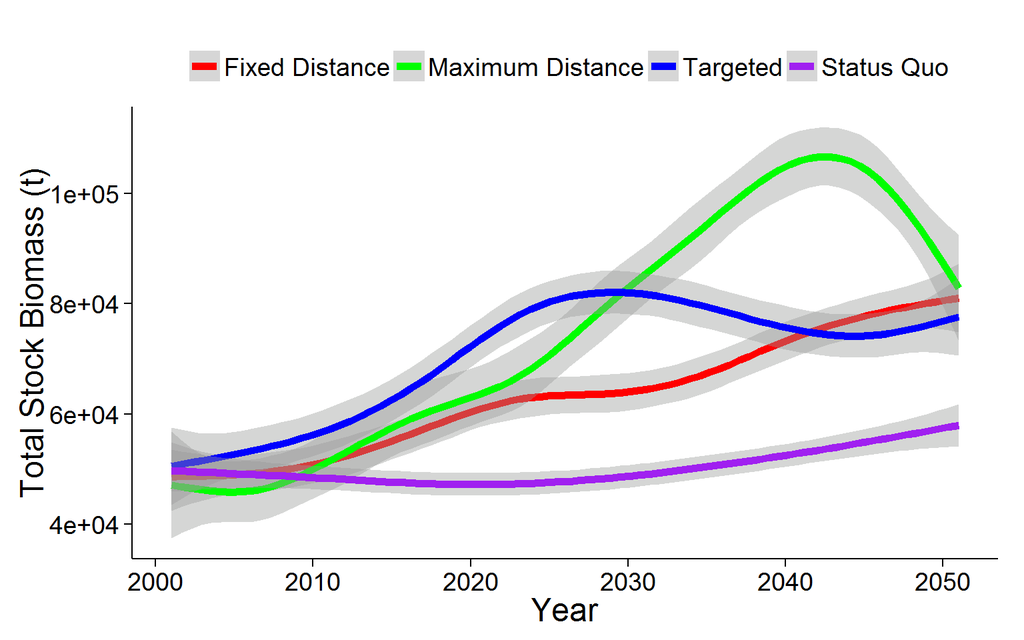

## Results: Catch

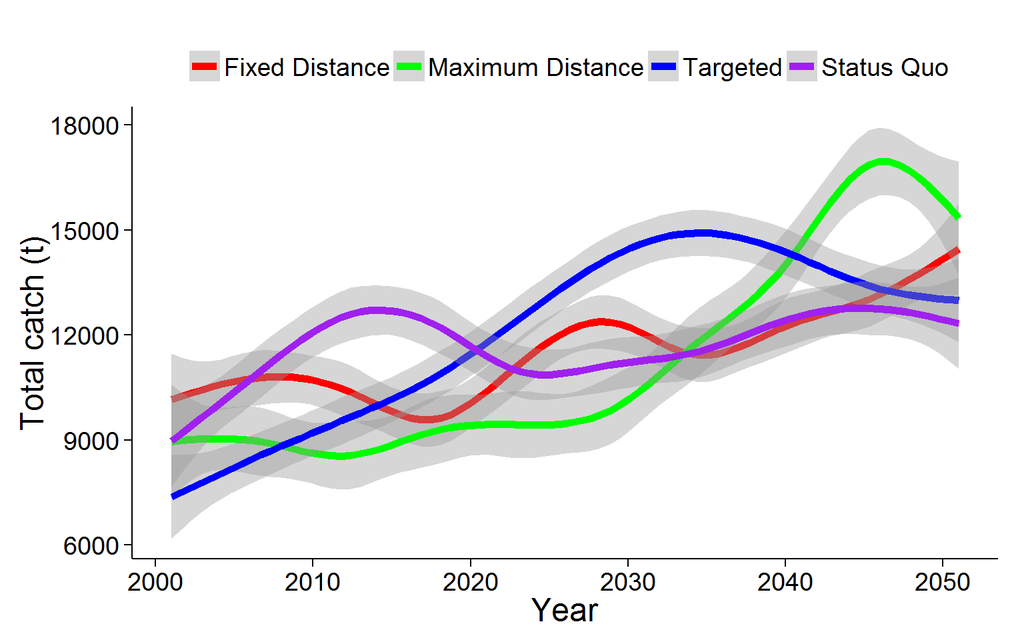

## Results: Distance

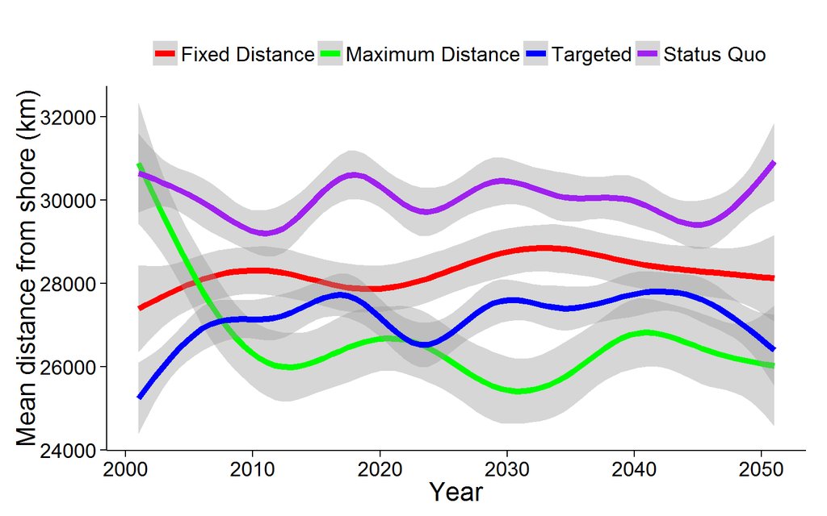

## Results: Present Value (SDR = 0.015)

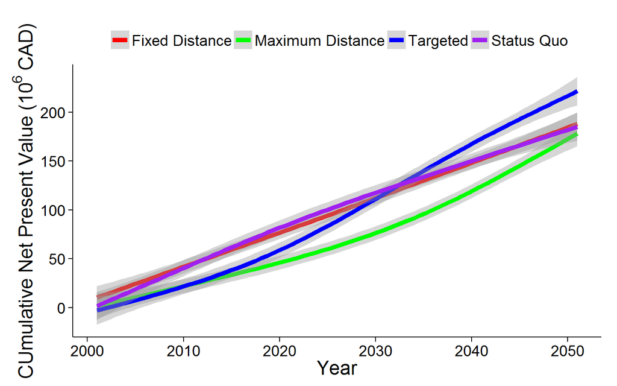

## Results: Present Value (SDR = 0.015)

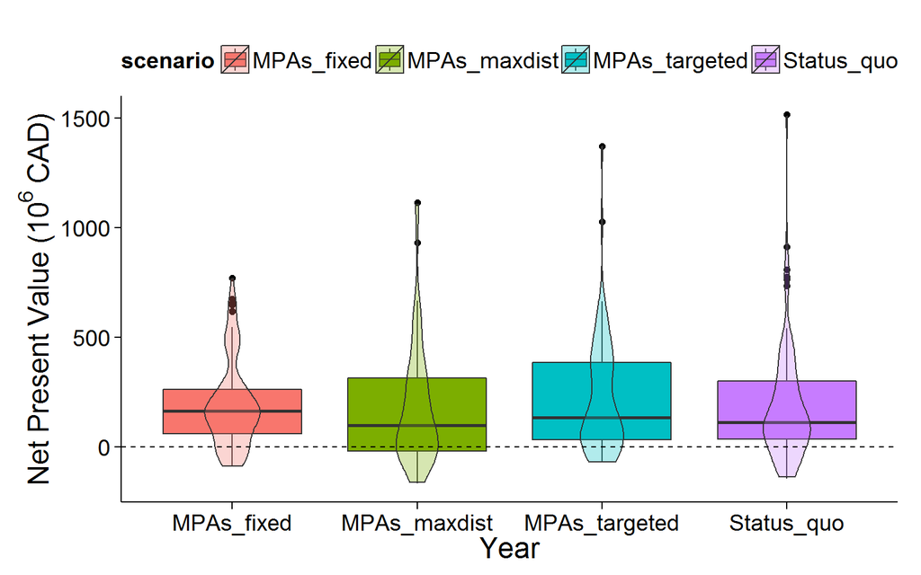

## Results: Present Value (SDR = 0.03)

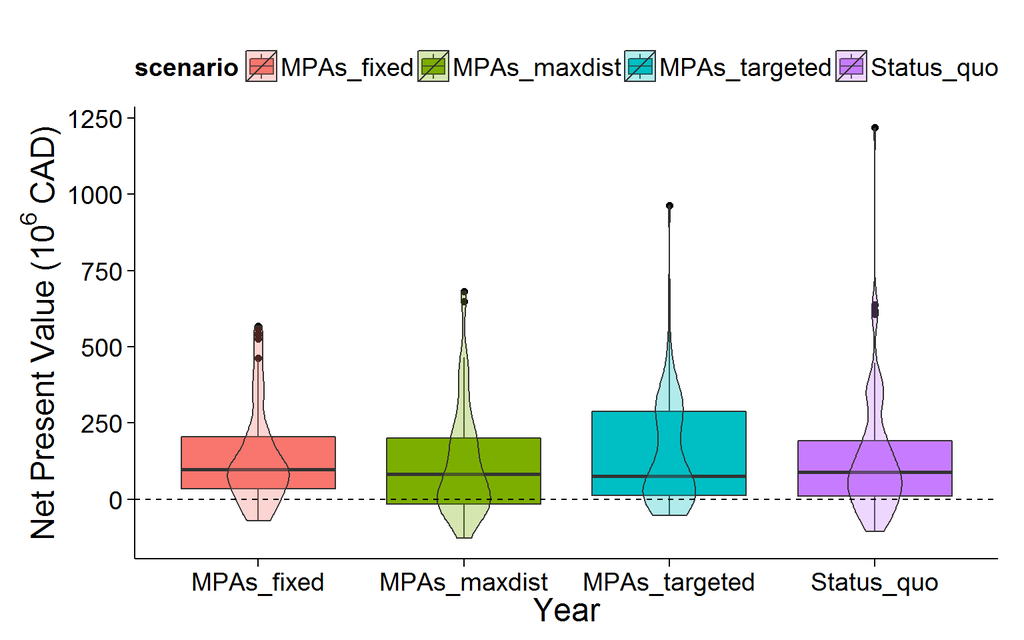

## Results: Present Value (SDR = 0.06)

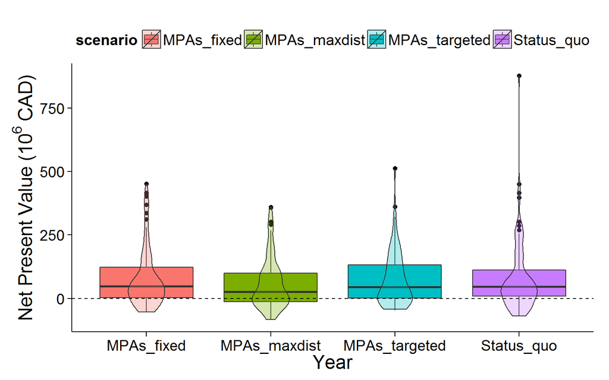

## Conclusions & Future directions

- The toolbox is a great way to evaluate MPA design strategies
- Some of the modules have room for improvent:
- Fishermen behaviour
- Dispersal

**Future:**

Implement the toolbox on the BC-cumumber project since we have pre-defined connectivity matrices.